# BraveRatsThesis

# Setup

allTurns = optimal gameplay data braverats = human data

```r
library(tidyverse)
library(tidyclust)
library(tclust)
library(tidymodels)
library(knitr)
```

## Nash optimal data

```r
source("readModelData.r")
```

## Human data

```r
#braverats <- read.csv("BraveRatsData.csv")
source("readHumanData.r")
```

```r
joined_human_ai <- braverats %>% left_join(allOptimalStrategies, by=c(paste("p1_c", 0:7, sep=''), paste("p2_c", 0:7, sep=''),
                                                "p1_wins", "p2_wins", "p1_holds", "p2_holds",
                                                "p1_spy", "p2_spy", "p1_general", "p2_general", "responding_to_card"))
```

```r
played_vs_optimal <- joined_human_ai %>%
  pivot_longer(cols = c("p1_o0","p1_o1","p1_o2","p1_o3","p1_o4","p1_o5","p1_o6","p1_o7"), names_to = "card_untrimmed", values_to = "optimal_prob") %>%
  mutate(this_card = substring(card_untrimmed, 5,6),
         this_card_played = if_else(P1==this_card, 1, 0),
         actual_card_played = P1,
         turn_type = ifelse(p1_spy, "Going Second", ifelse(p2_spy, "Going first", "Simultaneous"))) %>%
  select(Game, turn, p1_name, this_card, this_card_played, actual_card_played, optimal_prob, gamestate_str, p1_spy, p2_spy, turn_type) %>%
  filter(!is.na(optimal_prob)) # Removing invalid cards

#played_vs_optimal %>% sample_n(8)
```

# EDA

## Number of turns

Number of (non-terminal) states for each turn of game

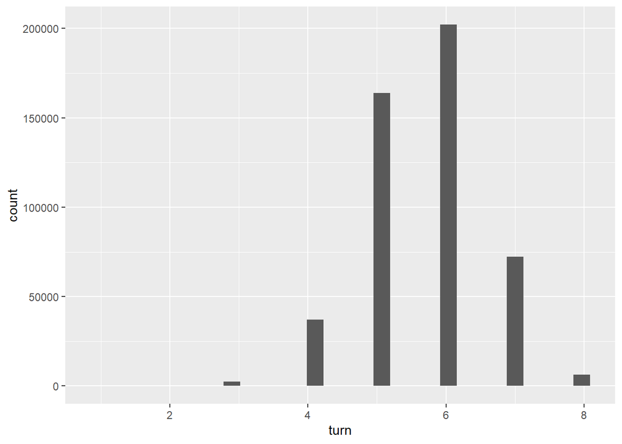

```r
allTurns %>%
  ggplot(aes(x = turn)) +
  geom_histogram()
```

```r
allTurns %>%
  group_by(turn) %>%
  summarize(count = n())
```

```
# A tibble: 8 × 2
   turn  count
  <dbl>  <int>
1     1      1
2     2     62
3     3   2448
4     4  37052
5     5 163938
6     6 202137
7     7  72269
8     8   6410
```

Distinct strategies by turn (counting multiple strategies on spy turns)

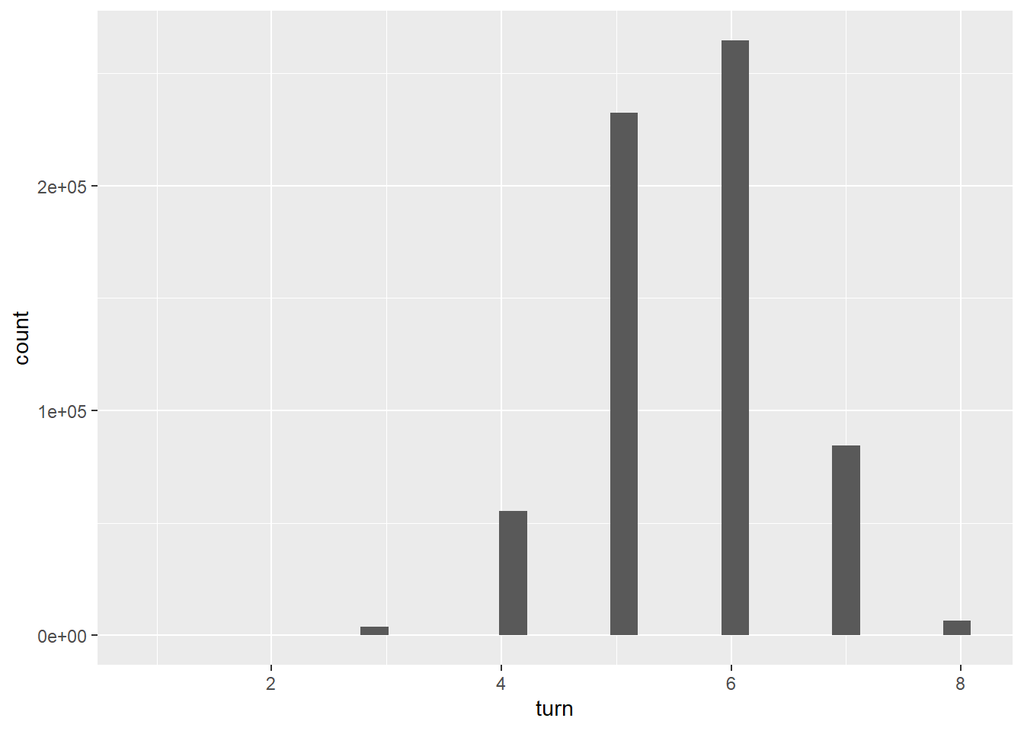

```r
allOptimalStrategies %>%
  ggplot(aes(x = turn)) +
  geom_histogram()
```

```r
allOptimalStrategies %>%
  group_by(turn) %>%
  summarize(count = n())
```

```
# A tibble: 8 × 2
   turn  count
  <dbl>  <int>
1     1      1
2     2     98
3     3   3813
4     4  55348
5     5 232443
6     6 264571
7     7  84393
8     8   6410
```

## Values of the turns

```r
# This is symmetrical, how to make it look like it?
mean(allTurns$value)
```

```
[1] 0.5
```

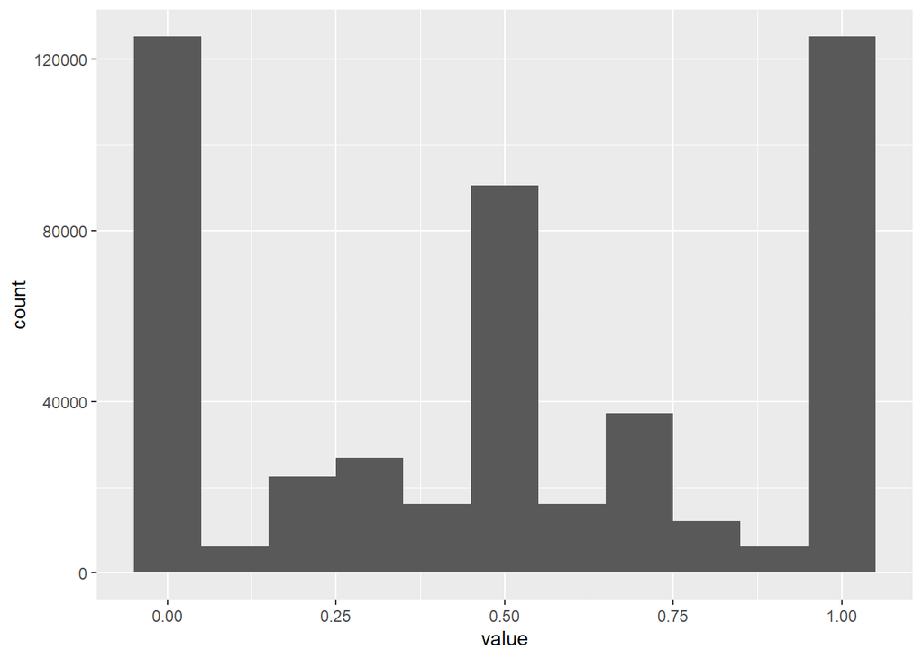

```r
allTurns %>%
  ggplot(aes(x = value)) +
  geom_histogram(binwidth = 0.1)
```

#### Plots of value by turn

```r
# Setting the bounds to make buckets symmetrical about 0.5.
# In order to achieve symmetry there must also be no datapoints on any breakpoints, so I widen them a tiny bit
# There are 21 buckets of just over 0.05 size.
lower_bound <- -0.025 + 0.000001
upper_bound <- 1.025 - 0.000001
breaks <- seq(lower_bound, upper_bound, by = ((upper_bound -lower_bound)/(21)))
#breaks <- seq(-0.05, 1.05, by = 0.1)

data_buckets <- cut(allTurns$value, breaks = breaks, include.lowest = TRUE)
table(data_buckets)
```

```
data_buckets
[-0.025,0.025]  (0.025,0.075]  (0.075,0.125]  (0.125,0.175]  (0.175,0.225]
        124875           1344           3419           5236           7099
 (0.225,0.275]  (0.275,0.325]  (0.325,0.375]  (0.375,0.425]  (0.425,0.475]
         13491           5491          22980           7398           8021
 (0.475,0.525]  (0.525,0.575]  (0.575,0.625]  (0.625,0.675]  (0.675,0.725]
         85609           8021           7398          22980           5491
 (0.725,0.775]  (0.775,0.825]  (0.825,0.875]  (0.875,0.925]  (0.925,0.975]
         13491           7099           5236           3419           1344
  (0.975,1.02]
        124875
```

```r
allTurns %>%
  filter(value == 0.025)
```

```
                                      p1_cards p2_cards wins generals spies
p1-0235-p2-0257-w-13-g-00-s-00-h-00       0235     0257   13       00    00
p1-02347-p2-02457-w-03-g-10-s-00-h-00    02347    02457   03       10    00
p1-01256-p2-01456-w-03-g-00-s-00-h-00    01256    01456   03       00    00
                                      holds value s1_type    p1_o0 p1_o1
p1-0235-p2-0257-w-13-g-00-s-00-h-00      00 0.025     s1s 0.199998
p1-02347-p2-02457-w-03-g-10-s-00-h-00    00 0.025     s1s 0.183334
p1-01256-p2-01456-w-03-g-00-s-00-h-00    00 0.025     s1s 0.266667   0.0
                                         p1_o2    p1_o3    p1_o4    p1_o5
p1-0235-p2-0257-w-13-g-00-s-00-h-00   0.249997 0.249997          0.300008
p1-02347-p2-02457-w-03-g-10-s-00-h-00 0.341662      0.0 0.475004
p1-01256-p2-01456-w-03-g-00-s-00-h-00      0.2                   0.266667
                                         p1_o6 p1_o7 s2_type    p2_o0 p2_o1
p1-0235-p2-0257-w-13-g-00-s-00-h-00                      s2s 0.249997
p1-02347-p2-02457-w-03-g-10-s-00-h-00            0.0     s2s      0.0
p1-01256-p2-01456-w-03-g-00-s-00-h-00 0.266667           s2s      0.2   0.0
                                         p2_o2 p2_o3    p2_o4    p2_o5    p2_o6
p1-0235-p2-0257-w-13-g-00-s-00-h-00   0.249997                0.300008
p1-02347-p2-02457-w-03-g-10-s-00-h-00 0.341662       0.475004      0.0
p1-01256-p2-01456-w-03-g-00-s-00-h-00                0.266667 0.266667 0.266667
                                         p2_o7
p1-0235-p2-0257-w-13-g-00-s-00-h-00   0.199998
p1-02347-p2-02457-w-03-g-10-s-00-h-00 0.183334
p1-01256-p2-01456-w-03-g-00-s-00-h-00
                                                                                                                                                                                               value_matrix
p1-0235-p2-0257-w-13-g-00-s-00-h-00                                                                        $ 0 $ 0.0,-0.0,0.0,0.125 $ 1 $ -0.0,0.1,0.0,0.0 $ 2 $ 0.1,0.0,0.0,0.0 $ 3 $ 0.0,0.0,0.083333,0.0
p1-02347-p2-02457-w-03-g-10-s-00-h-00  $ 0 $ 0.0,0.0,0.0,0.0,0.136364 $ 1 $ 0.0,0.073171,0.0,0.0,0.0 $ 2 $ 0.055556,0.0,0.0,0.19863,0.0 $ 3 $ 0.1,0.0,0.052632,0.135338,0.0 $ 4 $ 0.0,-0.0,0.0,0.097403,0.0
p1-01256-p2-01456-w-03-g-00-s-00-h-00           $ 0 $ 0.0,0.0,0.09375,0.0,0.0 $ 1 $ 0.083333,0.045455,0.0,0.0,0.0 $ 2 $ 0.125,0.125,0.0,0.0,0.0 $ 3 $ 0.0,0.0,0.0,0.09375,0.0 $ 4 $ 0.0,0.0,0.0,0.0,0.09375
                                                              gamestate_str
p1-0235-p2-0257-w-13-g-00-s-00-h-00     p1-0235-p2-0257-w-13-g-00-s-00-h-00
p1-02347-p2-02457-w-03-g-10-s-00-h-00 p1-02347-p2-02457-w-03-g-10-s-00-h-00
p1-01256-p2-01456-w-03-g-00-s-00-h-00 p1-01256-p2-01456-w-03-g-00-s-00-h-00
                                      cards_left turn p1_c0 p1_c1 p1_c2 p1_c3
p1-0235-p2-0257-w-13-g-00-s-00-h-00            4    5  TRUE FALSE  TRUE  TRUE
p1-02347-p2-02457-w-03-g-10-s-00-h-00          5    4  TRUE FALSE  TRUE  TRUE
p1-01256-p2-01456-w-03-g-00-s-00-h-00          5    4  TRUE  TRUE  TRUE FALSE
                                      p1_c4 p1_c5 p1_c6 p1_c7 p2_c0 p2_c1 p2_c2
p1-0235-p2-0257-w-13-g-00-s-00-h-00   FALSE  TRUE FALSE FALSE  TRUE FALSE  TRUE
p1-02347-p2-02457-w-03-g-10-s-00-h-00  TRUE FALSE FALSE  TRUE  TRUE FALSE  TRUE
p1-01256-p2-01456-w-03-g-00-s-00-h-00 FALSE  TRUE  TRUE FALSE  TRUE  TRUE FALSE
                                      p2_c3 p2_c4 p2_c5 p2_c6 p2_c7 p1_wins
p1-0235-p2-0257-w-13-g-00-s-00-h-00   FALSE FALSE  TRUE FALSE  TRUE       1
p1-02347-p2-02457-w-03-g-10-s-00-h-00 FALSE  TRUE  TRUE FALSE  TRUE       0
p1-01256-p2-01456-w-03-g-00-s-00-h-00 FALSE  TRUE  TRUE  TRUE FALSE       0
                                      p2_wins p1_general p2_general p1_spy
p1-0235-p2-0257-w-13-g-00-s-00-h-00         3      FALSE      FALSE  FALSE
p1-02347-p2-02457-w-03-g-10-s-00-h-00       3       TRUE      FALSE  FALSE
p1-01256-p2-01456-w-03-g-00-s-00-h-00       3      FALSE      FALSE  FALSE
                                      p2_spy p1_holds p2_holds
p1-0235-p2-0257-w-13-g-00-s-00-h-00    FALSE        0        0
p1-02347-p2-02457-w-03-g-10-s-00-h-00  FALSE        0        0
p1-01256-p2-01456-w-03-g-00-s-00-h-00  FALSE        0        0
```

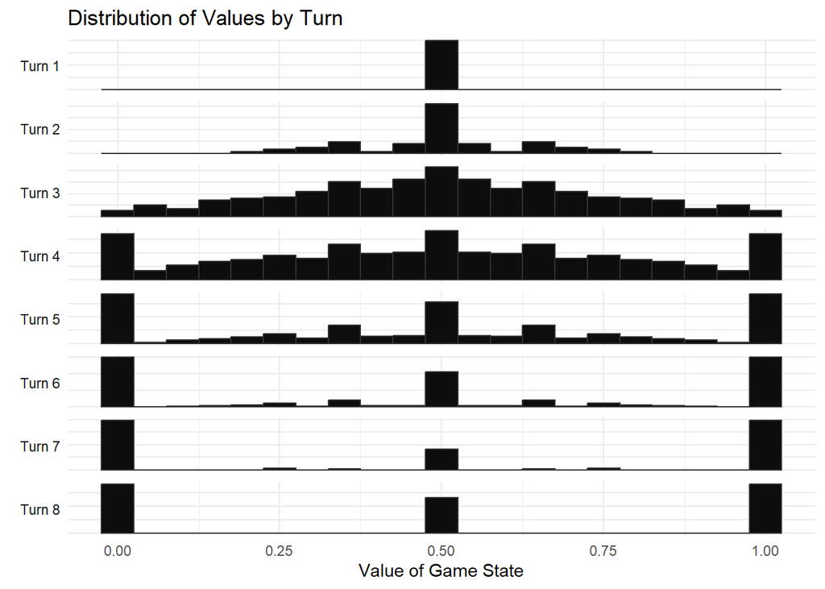

```r
allTurns %>%
  mutate(turn = paste0("Turn ", turn)) %>%
  ggplot(aes(x = value)) +
  geom_histogram(aes(y = ..density..), fill = 'grey5', color = "grey20", breaks = breaks) +
  facet_grid(rows = vars(turn), scales = "free_y", switch = "y")  +
  theme_minimal() +
  theme(
    strip.text.y.left = element_text(angle = 0, hjust = 0.5), # Rotate facet labels upright

    axis.line.y = element_blank(), # Hide the left y-axis line
    axis.text.y.left = element_blank(), # Hide the left y-axis text
    axis.ticks.y.left = element_blank(), # Hide the left y-axis ticks
    axis.title.y = element_blank(), # Remove y-axis label

    #panel.grid.major.y = element_line(), # Customize grid line appearance
    panel.grid.minor.y = element_blank() # Remove minor grid lines

  ) +
  labs(title = "Distribution of Values by Turn",
         x = "Value of Game State",
         y = "Proportion")
```

#### Proportion of turns that are either 1 or 0 by turn

```r
allTurns %>%
  mutate(turnType = ifelse(value==0 | value==1, "Value = 0 or 1", ifelse(value == 0.5, "Value = 0.5", "Other"))) %>%
  #mutate(turnType = ifelse(value==0, "Value = 0", ifelse(value==1, "Value = 1", "Value = 0.5"))) %>%
  group_by(turnType, turn) %>%
  summarize(n = n()) %>%
  pivot_wider(names_from = turnType, values_from = n, values_fill = 0) %>%
  arrange(turn)
```

```
# A tibble: 8 × 4
   turn Other `Value = 0 or 1` `Value = 0.5`
  <dbl> <int>            <int>         <int>
1     1     0                0             1
2     2    54                0             8
3     3  2334               48            66
4     4 28938             6180          1934
5     5 78724            61200         24014
6     6 38404           120984         42749
7     7  3926            56476         11867
8     8     0             4702          1708
```

# Exploration of MiniMax

## Average optimal by card

For each card, the distribution of what its optimal probability is when it’s an option.

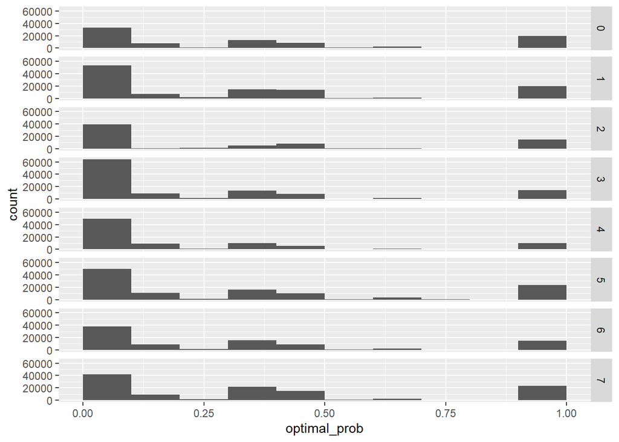

```r
card_optimals <- allOptimalStrategies %>%
  pivot_longer(cols = c("p1_o0","p1_o1","p1_o2","p1_o3","p1_o4","p1_o5","p1_o6","p1_o7"), names_prefix="p1_o", names_to = "card", values_to = "optimal_prob") %>%
  filter(!is.na(optimal_prob))

card_optimals %>%
  #filter(spies == "00") %>%
  filter(turn == 6) %>%
  ggplot(aes(x = optimal_prob)) +
  geom_histogram(breaks = seq(0, 1, by=0.1)) +
  facet_grid(rows = vars(card))
```

Average of each card, by turn

```r
card_avg_by_turn <- card_optimals %>%
  #filter(spies == "00") %>%
  select(card,turn,optimal_prob) %>%
  filter(!is.na(optimal_prob)) %>%
  group_by(card,turn) %>%
  summarize(avg_prob = mean(optimal_prob),
            sd = sd(optimal_prob))
# Avg probs by turn
card_avg_by_turn %>%
  select(card, avg_prob, turn) %>%
  pivot_wider(names_from = card, values_from = avg_prob) %>%
  round(2)
```

```
# A tibble: 8 × 9
   turn   `0`   `1`   `2`   `3`   `4`   `5`   `6`   `7`
  <dbl> <dbl> <dbl> <dbl> <dbl> <dbl> <dbl> <dbl> <dbl>
1     1  0     0     0.22  0.27  0.23  0.23  0     0.05
2     2  0.05  0.14  0.15  0.25  0.27  0.09  0.09  0.11
3     3  0.07  0.16  0.23  0.21  0.24  0.12  0.16  0.15
4     4  0.14  0.17  0.27  0.2   0.21  0.17  0.21  0.18
5     5  0.24  0.21  0.28  0.2   0.19  0.24  0.26  0.24
6     6  0.37  0.31  0.31  0.24  0.22  0.34  0.31  0.37
7     7  0.55  0.51  0.48  0.42  0.39  0.51  0.45  0.52
8     8  1     1     1     1     1     1     1     1
```

```r
# Sd of optimal probs by turn
card_avg_by_turn %>%
  select(card, sd, turn) %>%
  pivot_wider(names_from = card, values_from = sd) %>%
  round(2)
```

```
# A tibble: 8 × 9
   turn   `0`   `1`   `2`   `3`   `4`   `5`   `6`   `7`
  <dbl> <dbl> <dbl> <dbl> <dbl> <dbl> <dbl> <dbl> <dbl>
1     1 NA    NA    NA    NA    NA    NA    NA    NA
2     2  0.19  0.3   0.14  0.37  0.36  0.23  0.21  0.21
3     3  0.21  0.3   0.25  0.34  0.36  0.25  0.27  0.25
4     4  0.28  0.29  0.32  0.31  0.33  0.29  0.3   0.27
5     5  0.35  0.32  0.36  0.31  0.31  0.33  0.32  0.31
6     6  0.39  0.37  0.4   0.34  0.33  0.38  0.36  0.37
7     7  0.39  0.41  0.43  0.41  0.4   0.43  0.4   0.41
8     8  0     0     0     0     0     0     0     0
```

```r
# Adjusted probabilities
card_avg_by_turn %>%
  mutate(
    uniform_prob = 1 / (9-turn), # Uniform distribution's probability
    adjusted_avg_prob = avg_prob /uniform_prob) %>%
  select(card, adjusted_avg_prob, turn) %>%
  pivot_wider(names_from = card, values_from = adjusted_avg_prob) %>%
  round(2)
```

```
# A tibble: 8 × 9
   turn   `0`   `1`   `2`   `3`   `4`   `5`   `6`   `7`
  <dbl> <dbl> <dbl> <dbl> <dbl> <dbl> <dbl> <dbl> <dbl>
1     1  0     0     1.77  2.18  1.81  1.87  0     0.36
2     2  0.35  0.95  1.08  1.73  1.89  0.62  0.62  0.8
3     3  0.45  0.95  1.39  1.26  1.43  0.71  0.95  0.88
4     4  0.7   0.83  1.33  1     1.04  0.86  1.06  0.88
5     5  0.98  0.83  1.1   0.78  0.76  0.97  1.04  0.97
6     6  1.11  0.92  0.94  0.71  0.67  1.02  0.94  1.1
7     7  1.09  1.03  0.96  0.83  0.77  1.02  0.9   1.04
8     8  1     1     1     1     1     1     1     1
```

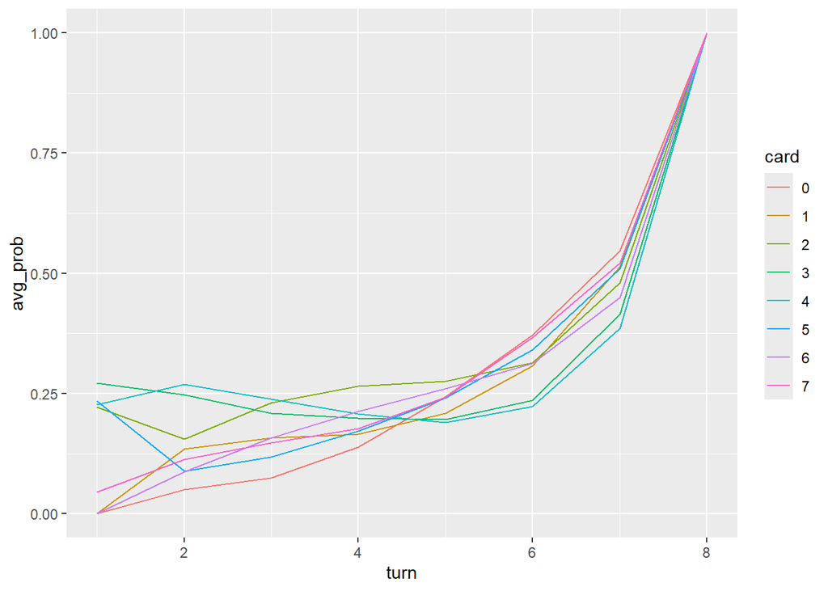

```r
card_avg_by_turn %>%
  ggplot(aes(x = turn, y = avg_prob, color = card)) +
  geom_line()
```

# Spy turns

Given that card X is in hand and you’ve been spied, how often is card X optimal to play?

```r
allOptimalStrategies %>%
  filter(p2_spy==1) %>%
  group_by(turn) %>%
  summarize(across(c("p1_o0","p1_o1","p1_o2","p1_o3","p1_o4","p1_o5","p1_o6","p1_o7"), ~mean(.x, na.rm=TRUE)))
```

```
# A tibble: 7 × 9
   turn p1_o0  p1_o1 p1_o2 p1_o3 p1_o4 p1_o5  p1_o6  p1_o7
  <dbl> <dbl>  <dbl> <dbl> <dbl> <dbl> <dbl>  <dbl>  <dbl>
1     2 0.4   0      0     0.2   0.2   0.333 0      0
2     3 0.239 0.0299 0.268 0.140 0.258 0.247 0.0977 0.0299
3     4 0.158 0.0962 0.353 0.149 0.282 0.230 0.202  0.101
4     5 0.196 0.144  0.303 0.152 0.273 0.354 0.341  0.222
5     6 0.256 0.237  0.267 0.213 0.230 0.500 0.439  0.457
6     7 0.409 0.463  0.407 0.402 0.339 0.638 0.567  0.660
7     8 1     1      1     1     1     1     1      1
```

A manual survey of what cards are optimal during different turns.

```r
spy_optimal_cards <- allOptimalStrategies %>%
  filter(p2_spy==TRUE) %>%
  #select(p1_cards, p2_cards, "p1_o0","p1_o1","p1_o2","p1_o3","p1_o4","p1_o5","p1_o6","p1_o7", "p2_o0","p2_o1","p2_o2","p2_o3","p2_o4","p2_o5","p2_o6","p2_o7") %>%
  # Extracting the optimal card for each player
  pivot_longer(cols = c( "p1_o0","p1_o1","p1_o2","p1_o3","p1_o4","p1_o5","p1_o6","p1_o7"), names_to = "p1_card", values_to = "optimal_prob") %>%
  filter(optimal_prob==1) %>%
  mutate(p1_card=as.factor(substring(p1_card,5,6))) %>%
  select(-optimal_prob) %>%
  pivot_longer(cols = c("p2_o0","p2_o1","p2_o2","p2_o3","p2_o4","p2_o5","p2_o6","p2_o7"), names_to = "p2_card", values_to = "optimal_prob") %>%
  filter(optimal_prob==1) %>%
  mutate(p2_card=as.factor(substring(p2_card,5,6))) %>%
  select(-optimal_prob)

spy_optimal_cards %>%
  filter(turn<=3) %>%
  select(p1_cards, p2_cards,wins, generals, holds, p1_card, p2_card) %>%
  sample_n(10)
```

```
# A tibble: 10 × 7
   p1_cards p2_cards wins  generals holds p1_card p2_card
   <chr>    <chr>    <chr> <chr>    <chr> <fct>   <fct>
 1 012567   013456   21    00       00    2       7
 2 012357   013457   11    10       00    0       7
 3 234567   013457   02    00       00    5       3
 4 012356   014567   11    00       00    0       3
 5 123457   013457   00    00       22    3       3
 6 023467   013567   11    00       00    4       7
 7 013456   013567   12    00       00    3       3
 8 012347   013467   20    10       00    0       7
 9 123467   013467   00    00       22    4       7
10 123457   014567   01    00       11    2       7
```

### Decision tree for spy turns

```r
library(rpart)
library(rpart.plot)


tree_mod <- decision_tree(mode = "classification", tree_depth = 3, cost_complexity = double(1)) %>%
  set_engine("rpart") %>%
  set_mode("classification")

spy_recipe = recipe(p1_card ~ #p1_c0+p1_c1+p1_c2+p1_c3+p1_c4+p1_c5+p1_c6+p1_c7+ # All gamestate information
          p2_c0+p2_c1+p2_c2+p2_c3+p2_c4+p2_c5+p2_c6+p2_c7+
          p1_wins+
         p2_wins+
         p1_general+p2_general+
         #p1_spy+p2_spy+
         p1_holds+p2_holds, data = spy_optimal_cards)

spy_wf = workflow() %>%
  add_recipe(spy_recipe) %>%
  add_model(tree_mod)

spy_fit <- spy_wf %>% fit(spy_optimal_cards)

tree_fitted <- spy_fit %>%
  extract_fit_parsnip()

tree_fitted
```

```
parsnip model object

n= 13885

node), split, n, loss, yval, (yprob)
      * denotes terminal node

 1) root 13885 11131 5 (0.11 0.11 0.13 0.11 0.079 0.2 0.14 0.12)
   2) p2_holds< 1.5 10338  8284 5 (0.14 0.076 0.15 0.14 0.097 0.2 0.13 0.068)
     4) p2_wins>=2.5 2900  2137 0 (0.26 0.13 0.068 0.027 0.053 0.23 0.097 0.13)
       8) p2_c5< 0.5 2035  1309 0 (0.36 0.16 0.075 0.033 0.052 0.16 0.07 0.1) *
       9) p2_c5>=0.5 865   501 5 (0.043 0.073 0.051 0.01 0.055 0.42 0.16 0.18) *
     5) p2_wins< 2.5 7438  6065 5 (0.097 0.055 0.18 0.18 0.11 0.18 0.14 0.046)
      10) p1_general>=0.5 1318   894 5 (0.099 0.045 0.25 0.11 0.15 0.32 0 0.022) *
      11) p1_general< 0.5 6120  4926 3 (0.097 0.057 0.17 0.2 0.11 0.16 0.17 0.051) *
   3) p2_holds>=1.5 3547  2531 7 (0 0.2 0.08 0.046 0.027 0.2 0.16 0.29)
     6) p2_c6< 0.5 2368  1683 1 (0 0.29 0.097 0.041 0.031 0.27 0.11 0.16)
      12) p2_c7>=0.5 963   477 1 (0 0.5 0.054 0.06 0.021 0.078 0.059 0.22) *
      13) p2_c7< 0.5 1405   847 5 (0 0.14 0.13 0.027 0.038 0.4 0.15 0.12) *
     7) p2_c6>=0.5 1179   544 7 (0 0.031 0.047 0.057 0.02 0.057 0.25 0.54)
      14) p2_c0>=0.5 234   111 6 (0 0.026 0.18 0.017 0.038 0.12 0.53 0.098) *
      15) p2_c0< 0.5 945   333 7 (0 0.032 0.014 0.067 0.015 0.042 0.18 0.65) *
```

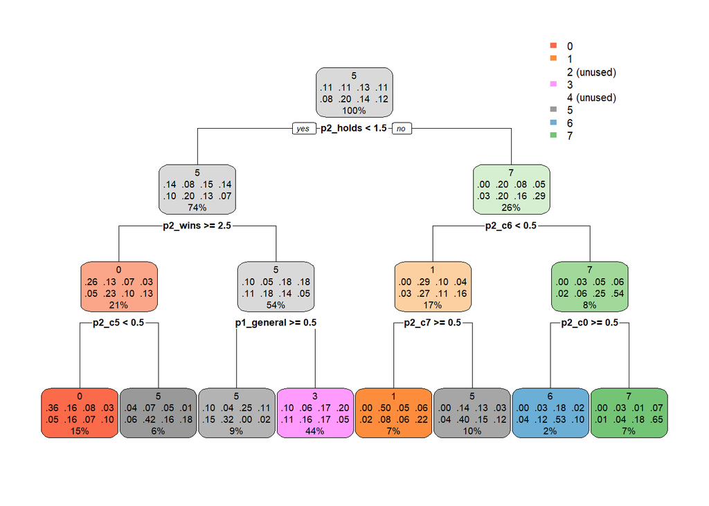

```r
rpart.plot(tree_fitted$fit)
```

# Human conformity to optimal

In this section, we’re looking at every card a player had the option to play, the optimal probability to play it, and whether they played it.

## Absolute mistakes

“Absolute mistake” = playing a card with optimal probability of 0. These plays are against theory, but may still be beneficial if you have a confident prediction about your opponent’s choice.

Which cards are most often played when they shouldn’t have?

### Mistakes in non-spy turns

Counts of all absolute mistakes made by card

```r
# Overall
played_vs_optimal %>%
  #filter(this_card_played == 1) %>%
  mutate(is_viable = ifelse(optimal_prob == 0, "Not Viable", "Viable")) %>%
  group_by(is_viable, this_card_played) %>%
  summarize(n = n()) %>%
  pivot_wider(names_from = is_viable, values_from = n) %>%
  mutate(viability_rate = Viable / (Viable + `Not Viable`))
```

```
# A tibble: 2 × 4
  this_card_played `Not Viable` Viable viability_rate
             <dbl>        <int>  <int>          <dbl>
1                0         3018   2918          0.492
2                1          369    905          0.710
```

```r
# By turn
played_vs_optimal %>%
  filter(this_card_played == 1) %>%
  mutate(is_viable = ifelse(optimal_prob == 0, "Not Viable", "Viable")) %>%
  group_by(is_viable, turn) %>%
  summarize(n = n()) %>%
  pivot_wider(names_from = is_viable, values_from = n, values_fill = 0) %>%
  mutate(total = Viable + `Not Viable`,
         viability_rate = Viable / (total)) %>%
  # Add 95% Confidence Intervals
  mutate(conf_lower = purrr::map2_dbl(Viable, total,
                                       ~ binom.test(.x, .y, alternative = "two.sided", conf.level = 0.95)$conf.int[1]),
         conf_upper = purrr::map2_dbl(Viable, total,
                                       ~ binom.test(.x, .y, alternative = "two.sided", conf.level = 0.95)$conf.int[2]))
```

```
# A tibble: 8 × 7
   turn `Not Viable` Viable total viability_rate conf_lower conf_upper
  <dbl>        <int>  <int> <int>          <dbl>      <dbl>      <dbl>
1     1           27    219   246          0.890      0.844      0.926
2     2           89    157   246          0.638      0.575      0.698
3     3           73    167   240          0.696      0.633      0.753
4     4           79    123   202          0.609      0.538      0.677
5     5           51     97   148          0.655      0.573      0.732
6     6           35     81   116          0.698      0.606      0.780
7     7           15     39    54          0.722      0.584      0.835
8     8            0     22    22          1          0.846      1
```

```r
# By turn type
played_vs_optimal %>%
  filter(this_card_played == 1) %>%
  mutate(is_viable = ifelse(optimal_prob == 0, "Not Viable", "Viable")) %>%
  group_by(is_viable, turn_type) %>%
  summarize(n = n()) %>%
  pivot_wider(names_from = is_viable, values_from = n) %>%
  mutate(total = Viable + `Not Viable`,
         viability_rate = Viable / (total)) %>%
  # Add 95% Confidence Intervals
  mutate(conf_lower = purrr::map2_dbl(Viable, total,
                                       ~ binom.test(.x, .y, alternative = "two.sided", conf.level = 0.95)$conf.int[1]),
         conf_upper = purrr::map2_dbl(Viable, total,
                                       ~ binom.test(.x, .y, alternative = "two.sided", conf.level = 0.95)$conf.int[2]))
```

```
# A tibble: 3 × 7
  turn_type    `Not Viable` Viable total viability_rate conf_lower conf_upper
  <chr>               <int>  <int> <int>          <dbl>      <dbl>      <dbl>
1 Going Second           57     62   119          0.521      0.428      0.613
2 Going first            71     48   119          0.403      0.314      0.497
3 Simultaneous          241    795  1036          0.767      0.740      0.793
```

```r
# By turn type and turn
played_vs_optimal %>%
  filter(this_card_played == 1) %>%
  mutate(is_viable = ifelse(optimal_prob == 0, "Not Viable", "Viable")) %>%
  group_by(is_viable, turn_type, turn) %>%
  summarize(n = n()) %>%
  pivot_wider(names_from = is_viable, values_from = n, values_fill = 0) %>%
  mutate(total = Viable + `Not Viable`,
         viability_rate = Viable / (total)) %>%
  # Add 95% Confidence Intervals
  mutate(conf_lower = purrr::map2_dbl(Viable, total,
                                       ~ binom.test(.x, .y, alternative = "two.sided",
                                                    conf.level = 0.95)$conf.int[1]),
         conf_upper = purrr::map2_dbl(Viable, total,
                                       ~ binom.test(.x, .y, alternative = "two.sided",
                                                    conf.level = 0.95)$conf.int[2])) %>%
  arrange(turn_type, turn)
```

```
# A tibble: 20 × 8
# Groups:   turn_type [3]
   turn_type     turn `Not Viable` Viable total viability_rate conf_lower
   <chr>        <dbl>        <int>  <int> <int>          <dbl>      <dbl>
 1 Going Second     2           35     14    49          0.286     0.166
 2 Going Second     3           12     12    24          0.5       0.291
 3 Going Second     4            8     18    26          0.692     0.482
 4 Going Second     5            2      6     8          0.75      0.349
 5 Going Second     6            0      9     9          1         0.664
 6 Going Second     7            0      3     3          1         0.292
 7 Going first      2           25     24    49          0.490     0.344
 8 Going first      3           15      9    24          0.375     0.188
 9 Going first      4           20      6    26          0.231     0.0897
10 Going first      5            4      4     8          0.5       0.157
11 Going first      6            7      2     9          0.222     0.0281
12 Going first      7            0      3     3          1         0.292
13 Simultaneous     1           27    219   246          0.890     0.844
14 Simultaneous     2           29    119   148          0.804     0.731
15 Simultaneous     3           46    146   192          0.760     0.694
16 Simultaneous     4           51     99   150          0.66      0.578
17 Simultaneous     5           45     87   132          0.659     0.572
18 Simultaneous     6           28     70    98          0.714     0.614
19 Simultaneous     7           15     33    48          0.688     0.537
20 Simultaneous     8            0     22    22          1         0.846
# ℹ 1 more variable: conf_upper <dbl>
```

When only 1 card is viable?

```r
# Overall
played_vs_optimal %>%
  filter(optimal_prob == 1) %>%
  mutate(card_played = ifelse(this_card_played == 1, "Played", "Not Played")) %>%
  group_by(card_played, turn_type) %>%
  summarize(n = n()) %>%
  pivot_wider(names_from = card_played, values_from = n) %>%
  mutate(accuracy = Played/(Played + `Not Played`))
```

```
# A tibble: 3 × 4
  turn_type    `Not Played` Played accuracy
  <chr>               <int>  <int>    <dbl>
1 Going Second           56     38    0.404
2 Going first            68     42    0.382
3 Simultaneous           74    100    0.575
```

```r
# By turn
played_vs_optimal %>%
  filter(optimal_prob == 1) %>%
  mutate(card_played = ifelse(this_card_played == 1, "Played", "Not Played"),
         turn_type = ifelse(p1_spy, "Going Second", ifelse(p2_spy, "Going first", "Simultaneous"))) %>%
  group_by(card_played, turn_type, turn) %>%
  summarize(n = n()) %>%
  pivot_wider(names_from = card_played, values_from = n) %>%
  mutate(accuracy = Played/(Played + `Not Played`)) %>%
  arrange(turn_type, turn)
```

```
# A tibble: 18 × 5
# Groups:   turn_type [3]
   turn_type     turn `Not Played` Played accuracy
   <chr>        <dbl>        <int>  <int>    <dbl>
 1 Going Second     2           35     14    0.286
 2 Going Second     3           12     10    0.455
 3 Going Second     4            7      7    0.5
 4 Going Second     5            2      2    0.5
 5 Going Second     6           NA      2   NA
 6 Going Second     7           NA      3   NA
 7 Going first      2           25     24    0.490
 8 Going first      3           15      8    0.348
 9 Going first      4           19      6    0.24
10 Going first      5            3      4    0.571
11 Going first      6            6     NA   NA
12 Simultaneous     2            2      8    0.8
13 Simultaneous     3            2     NA   NA
14 Simultaneous     4           13      6    0.316
15 Simultaneous     5           23     23    0.5
16 Simultaneous     6           19     24    0.558
17 Simultaneous     7           15     17    0.531
18 Simultaneous     8           NA     22   NA
```

```r
# Ad-hoc: what are the turn-2 simultaneus moves with a 100% best choice?
# If you play general into ambassador first turn, wizard into assassin is a pure play
played_vs_optimal %>%
  filter(optimal_prob == 1) %>%
  mutate(card_played = ifelse(this_card_played == 1, "Played", "Not Played"),
         turn_type = ifelse(p1_spy, "Going Second", ifelse(p2_spy, "Going first", "Simultaneous"))) %>%
  filter(turn_type == "Simultaneous", turn == 2)
```

```
# A tibble: 10 × 12
    Game  turn p1_name this_card this_card_played actual_card_played
   <int> <dbl> <chr>   <chr>                <dbl>              <int>
 1    41     2 William 3                        1                  3
 2    54     2 William 3                        1                  3
 3    60     2 William 3                        1                  3
 4    87     2 William 3                        1                  3
 5   104     2 William 3                        1                  3
 6    41     2 Michael 5                        0                  7
 7    54     2 Sean    5                        0                  1
 8    60     2 Sean    5                        1                  5
 9    87     2 Jake    5                        1                  5
10   104     2 Sean    5                        1                  5
# ℹ 6 more variables: optimal_prob <dbl>, gamestate_str <chr>, p1_spy <lgl>,
#   p2_spy <lgl>, turn_type <chr>, card_played <chr>
```

```r
played_vs_optimal %>%
  filter(p1_spy == FALSE & p2_spy == FALSE, optimal_prob == 0, this_card_played == 1) %>%
  group_by(this_card) %>% #, turn
  summarise(n_mistakes = n())
```

```
# A tibble: 8 × 2
  this_card n_mistakes
  <chr>          <int>
1 0                 35
2 1                 34
3 2                 15
4 3                 18
5 4                 26
6 5                 36
7 6                 56
8 7                 21
```

Turn-by-turn view: Column = card, row = turn of game. The most common “absolute mistakes” are playing the 6 card on turn 1, the 0 card on turn 3, and the 1 card on turn 5.

```r
played_vs_optimal %>%
  filter(p1_spy == FALSE & p2_spy == FALSE, optimal_prob == 0, this_card_played == 1) %>%
  group_by(this_card, turn) %>% #
  summarise(n_mistakes = n()) %>%
  pivot_wider(names_from = this_card, values_from = n_mistakes, id_cols = turn)
```

```
# A tibble: 7 × 9
   turn   `0`   `1`   `2`   `3`   `4`   `5`   `6`   `7`
  <dbl> <int> <int> <int> <int> <int> <int> <int> <int>
1     1     5     2    NA    NA    NA    NA    20    NA
2     2     5     4     5    NA     4     4     5     2
3     3    12     3     1     7     4     9     5     5
4     4     8    10     3     6     7     6     8     3
5     5     5    11     4     2     6     7     6     4
6     6    NA     4     1    NA     3     5    10     5
7     7    NA    NA     1     3     2     5     2     2
```

### Spy turns

####When going first (opponent used spy):

```r
# Overall
played_vs_optimal %>%
  filter(p1_spy == FALSE & p2_spy == TRUE, optimal_prob == 0, this_card_played == 1) %>%
  group_by(this_card) %>% #, turn
  summarise(n_mistakes = n())
```

```
# A tibble: 8 × 2
  this_card n_mistakes
  <chr>          <int>
1 0                 37
2 1                  5
3 2                  3
4 3                  2
5 4                  2
6 5                 11
7 6                  6
8 7                  5
```

```r
# Turn by turn
played_vs_optimal %>%
  filter(p1_spy == FALSE & p2_spy == TRUE, optimal_prob == 0, this_card_played == 1) %>%
  group_by(this_card, turn) %>% #
  summarise(n_mistakes = n()) %>%
  pivot_wider(names_from = this_card, values_from = n_mistakes, id_cols = turn)
```

```
# A tibble: 5 × 9
   turn   `0`   `1`   `2`   `3`   `4`   `5`   `6`   `7`
  <dbl> <int> <int> <int> <int> <int> <int> <int> <int>
1     2    14     1     3     1     1     3     2    NA
2     3    12    NA    NA    NA    NA     2     1    NA
3     4     8     1    NA    NA     1     3     3     4
4     5     2     1    NA    NA    NA     1    NA    NA
5     6     1     2    NA     1    NA     2    NA     1
```

What should’ve been played instead? (by turn)

```r
# Turn by turn
played_vs_optimal %>%
  filter(p1_spy == FALSE & p2_spy == TRUE, optimal_prob > 0, this_card_played == 0) %>%
  group_by(this_card, turn) %>% #
  summarise(n_mistakes = n()) %>%
  pivot_wider(names_from = this_card, values_from = n_mistakes, id_cols = turn)
```

```
# A tibble: 6 × 9
   turn   `0`   `1`   `2`   `3`   `4`   `5`   `6`   `7`
  <dbl> <int> <int> <int> <int> <int> <int> <int> <int>
1     2     6    NA    NA    15     1     3    NA    NA
2     3     1    NA     7     3     2     1     3    NA
3     4     2     2     5     4     3     2     2     1
4     5     1     1    NA     1     1    NA     1    NA
5     6    NA     2     1     1     1     1     2     2
6     7    NA    NA    NA     1    NA    NA     2    NA
```

Actual card vs. optimal card/cards

```r
played_vs_optimal %>%
  filter(turn==3) %>%
  filter(p1_spy == FALSE & p2_spy == TRUE, optimal_prob > 0, this_card_played == 0) %>%
  group_by(this_card, actual_card_played) %>% #
  summarise(n_mistakes = n()) %>%
  pivot_wider(names_from = this_card, values_from = n_mistakes, id_cols = actual_card_played) %>%
  arrange(actual_card_played)
```

```
# A tibble: 4 × 7
  actual_card_played   `0`   `2`   `3`   `4`   `5`   `6`
               <int> <int> <int> <int> <int> <int> <int>
1                  0    NA     4     3     2     1     2
2                  2     1    NA    NA    NA    NA     1
3                  5    NA     2    NA    NA    NA    NA
4                  6    NA     1    NA    NA    NA    NA
```

```r
# Overall
played_vs_optimal %>%
  filter(p1_spy == TRUE & p2_spy == FALSE, optimal_prob == 0, this_card_played == 1) %>%
  group_by(this_card) %>% #, turn
  summarise(n_mistakes = n())
```

```
# A tibble: 7 × 2
  this_card n_mistakes
  <chr>          <int>
1 0                  4
2 1                  3
3 3                  8
4 4                 16
5 5                 11
6 6                 10
7 7                  5
```

```r
# Turn by turn
played_vs_optimal %>%
  filter(p1_spy == TRUE & p2_spy == FALSE, optimal_prob == 0, this_card_played == 1) %>%
  group_by(this_card, turn) %>% #
  summarise(n_mistakes = n()) %>%
  pivot_wider(names_from = this_card, values_from = n_mistakes, id_cols = turn)
```

```
# A tibble: 4 × 8
   turn   `0`   `1`   `3`   `4`   `5`   `6`   `7`
  <dbl> <int> <int> <int> <int> <int> <int> <int>
1     2     1     2     7    11     7     5     2
2     4     3     1    NA     1     2     1    NA
3     3    NA    NA     1     4     2     3     2
4     5    NA    NA    NA    NA    NA     1     1
```

What should’ve been played instead? (by turn)

```r
# Turn by turn
played_vs_optimal %>%
  filter(p1_spy == TRUE & p2_spy == FALSE, optimal_prob > 0, this_card_played == 0) %>%
  group_by(this_card, turn) %>% #
  summarise(n_mistakes = n()) %>%
  pivot_wider(names_from = this_card, values_from = n_mistakes, id_cols = turn)
```

```
# A tibble: 5 × 8
   turn   `0`   `1`   `3`   `4`   `5`   `6`   `7`
  <dbl> <int> <int> <int> <int> <int> <int> <int>
1     2     3    16     3    11    NA     2    NA
2     3     1     6     3     2     4     1     2
3     4     3     7     4     1     3     6     1
4     5     2     2     2     1    NA     2    NA
5     6     4     2    NA     1     1    NA     1
```

Actual card vs. optimal card/cards

```r
played_vs_optimal %>%
  filter(turn==3) %>%
  filter(p1_spy == TRUE & p2_spy == FALSE, optimal_prob > 0, this_card_played == 0) %>%
  group_by(this_card, actual_card_played) %>% #
  summarise(n_mistakes = n()) %>%
  pivot_wider(names_from = this_card, values_from = n_mistakes, id_cols = actual_card_played) %>%
  arrange(actual_card_played)
```

```
# A tibble: 6 × 8
  actual_card_played   `0`   `1`   `3`   `4`   `5`   `6`   `7`
               <int> <int> <int> <int> <int> <int> <int> <int>
1                  0    NA     1    NA    NA    NA    NA     1
2                  3    NA    NA    NA     1    NA    NA    NA
3                  4     1     3     1    NA     2     1     1
4                  5    NA    NA     2    NA    NA    NA    NA
5                  6    NA     1    NA     1     1    NA    NA
6                  7    NA     1    NA    NA     1    NA    NA
```

#### Looking at specific error turns

Change the filters here to see the type of turn you want

```r
played_vs_optimal %>%
  filter(this_card == 4) %>% #, turn == 2) %>% # Edit this
  filter(p1_spy == TRUE & p2_spy == FALSE, optimal_prob > 0, this_card_played == 0)
```

```
# A tibble: 16 × 11
    Game  turn p1_name this_card this_card_played actual_card_played
   <int> <dbl> <chr>   <chr>                <dbl>              <int>
 1    16     2 William 4                        0                  3
 2    17     3 William 4                        0                  6
 3    52     2 William 4                        0                  6
 4    55     2 William 4                        0                  3
 5    95     6 William 4                        0                  7
 6   101     3 William 4                        0                  3
 7   106     2 William 4                        0                  3
 8   121     4 William 4                        0                  6
 9     4     2 Kiran   4                        0                  5
10    14     2 Kiran   4                        0                  6
11    31     2 Michael 4                        0                  3
12    38     2 Michael 4                        0                  3
13    45     2 Michael 4                        0                  3
14    83     2 Michael 4                        0                  5
15    96     5 Chanel  4                        0                  1
16   118     2 Chris   4                        0                  5
# ℹ 5 more variables: optimal_prob <dbl>, gamestate_str <chr>, p1_spy <lgl>,
#   p2_spy <lgl>, turn_type <chr>
```

```r
allTurns %>% filter(gamestate_str == 'p1-0134567-p2-0123567-w-02-g-00-s-10-h-00')
```

```
                                          p1_cards p2_cards wins generals spies
p1-0134567-p2-0123567-w-02-g-00-s-10-h-00  0134567  0123567   02       00    10
                                          holds    value s1_type p1_o0 p1_o1
p1-0134567-p2-0123567-w-02-g-00-s-10-h-00    00 0.289402     s1r     4     4
                                          p1_o2 p1_o3 p1_o4 p1_o5 p1_o6 p1_o7
p1-0134567-p2-0123567-w-02-g-00-s-10-h-00     4     0           6     3     1
                                          s2_type p2_o0 p2_o1 p2_o2 p2_o3 p2_o4
p1-0134567-p2-0123567-w-02-g-00-s-10-h-00     s2f   0.0   0.0   0.0   1.0
                                          p2_o5 p2_o6 p2_o7
p1-0134567-p2-0123567-w-02-g-00-s-10-h-00   0.0   0.0   0.0
                                                                                                                                                                                                                                                                                                            …
p1-0134567-p2-0123567-w-02-g-00-s-10-h-00  $ 0 $ 0.260296,0.233487,0.0,0.289402,0.116556,0.213796,0.388572 $ 1 $ 0.206376,0.192162,0.0,0.279117,0.101636,0.038217,1.0 $ 2 $ 0.26432,0.070104,0.0,0.272314,0.207678,0.392281,0.134884 $ 3 $ 0.371299,0.464849,0.345783,0.068538,0.194201,0.07573,0.119189 $ 4…
                                                                      gamestate_str
p1-0134567-p2-0123567-w-02-g-00-s-10-h-00 p1-0134567-p2-0123567-w-02-g-00-s-10-h-00
                                          cards_left turn p1_c0 p1_c1 p1_c2
p1-0134567-p2-0123567-w-02-g-00-s-10-h-00          7    2  TRUE  TRUE FALSE
                                          p1_c3 p1_c4 p1_c5 p1_c6 p1_c7 p2_c0
p1-0134567-p2-0123567-w-02-g-00-s-10-h-00  TRUE  TRUE  TRUE  TRUE  TRUE  TRUE
                                          p2_c1 p2_c2 p2_c3 p2_c4 p2_c5 p2_c6
p1-0134567-p2-0123567-w-02-g-00-s-10-h-00  TRUE  TRUE  TRUE FALSE  TRUE  TRUE
                                          p2_c7 p1_wins p2_wins p1_general
p1-0134567-p2-0123567-w-02-g-00-s-10-h-00  TRUE       0       2      FALSE
                                          p2_general p1_spy p2_spy p1_holds
p1-0134567-p2-0123567-w-02-g-00-s-10-h-00      FALSE   TRUE  FALSE        0
                                          p2_holds
p1-0134567-p2-0123567-w-02-g-00-s-10-h-00        0
```

## Error rates by player

#### Non-spy turns

```r
played_vs_optimal %>%
  filter(this_card_played == 1, !is.na(optimal_prob)) %>%
  filter(p1_spy == FALSE & p2_spy == FALSE) %>%
  mutate(absolute_mistake = if_else(this_card_played == 1 & optimal_prob == 0, 1, 0)) %>%
  group_by(p1_name) %>%
  summarize(total_mistakes = sum(absolute_mistake),
            total_plays = n(),
            mistake_ratio = mean(absolute_mistake)) %>%
  # Add 95% Confidence Intervals
  mutate(conf_lower = purrr::map2_dbl(total_mistakes, total_plays,
                                       ~ binom.test(.x, .y, alternative = "two.sided",
                                                    conf.level = 0.95)$conf.int[1]),
         conf_upper = purrr::map2_dbl(total_mistakes, total_plays,
                                       ~ binom.test(.x, .y, alternative = "two.sided",
                                                    conf.level = 0.95)$conf.int[2])) %>%
  arrange(-total_plays)
```

```
# A tibble: 11 × 6
   p1_name   total_mistakes total_plays mistake_ratio conf_lower conf_upper
   <chr>              <dbl>       <int>         <dbl>      <dbl>      <dbl>
 1 William               96         482         0.199    0.164        0.238
 2 Sean                  38         140         0.271    0.200        0.353
 3 Michael               33         117         0.282    0.203        0.373
 4 Kiran                 26          93         0.280    0.191        0.382
 5 Daniel                 7          48         0.146    0.0607       0.278
 6 Chris                 13          46         0.283    0.160        0.435
 7 Chanel                11          44         0.25     0.132        0.403
 8 Amanda                 4          29         0.138    0.0389       0.317
 9 Jake                   7          21         0.333    0.146        0.570
10 Carson                 5           9         0.556    0.212        0.863
11 Katherine              1           7         0.143    0.00361      0.579
```

#### Spy turns

```r
# Pivot to a longer form with player_spied describing which player was spied
played_vs_optimal %>%
  filter(this_card_played == 1, !is.na(optimal_prob)) %>%
  filter(p1_spy == TRUE | p2_spy == TRUE) %>%
  pivot_longer(c(p1_spy, p2_spy), names_to = "player_spied") %>%
  filter(value == TRUE) %>% select(-value) %>%
  mutate(absolute_mistake = if_else(this_card_played == 1 & optimal_prob == 0, 1, 0)) %>%
  group_by(p1_name, player_spied) %>%
  summarize(total_mistakes = sum(absolute_mistake),
            total_plays = n(),
            mistake_ratio = mean(absolute_mistake)) %>%
  arrange(-total_plays, player_spied) %>% head()
```

```
# A tibble: 6 × 5
# Groups:   p1_name [3]
  p1_name player_spied total_mistakes total_plays mistake_ratio
  <chr>   <chr>                 <dbl>       <int>         <dbl>
1 William p1_spy                   26          63         0.413
2 William p2_spy                   29          49         0.592
3 Kiran   p2_spy                   10          16         0.625
4 Sean    p1_spy                    7          15         0.467
5 Sean    p2_spy                   10          13         0.769
6 Kiran   p1_spy                    8          12         0.667
```

## Non-absolute errors

### First turn table

```r
played_vs_optimal %>%
  filter(turn == 1, this_card_played == 1) %>%
  group_by(this_card) %>%
  summarize(n_plays = n(),
            optimal_prob = mean(optimal_prob)) %>%
  mutate(observed_prob = n_plays / sum(n_plays),
         expected_plays = optimal_prob * sum(n_plays)) %>%
  kable(digits = 3)
```

| this_card | n_plays | optimal_prob | observed_prob | expected_plays |
| --- | --- | --- | --- | --- |
| 0 | 5 | 0.000 | 0.020 | 0.000 |
| 1 | 2 | 0.000 | 0.008 | 0.000 |
| 2 | 76 | 0.222 | 0.309 | 54.553 |
| 3 | 49 | 0.272 | 0.199 | 66.891 |
| 4 | 55 | 0.227 | 0.224 | 55.805 |
| 5 | 27 | 0.234 | 0.110 | 57.631 |
| 6 | 20 | 0.000 | 0.081 | 0.000 |
| 7 | 12 | 0.045 | 0.049 | 11.121 |

#### Overall proportions played by bucket.

Here, we put a player’s options into “buckets” based on how often they should optimally play it.

```r
prob_buckets <- played_vs_optimal %>%
  #filter(optimal_prob > 0) %>%
  #filter(p1_spy == FALSE & p2_spy == FALSE) %>%
  #mutate(prob_bucket = ceiling(optimal_prob*10)/10) %>%
    mutate(prob_bucket = ifelse(optimal_prob == 1, 1, ceiling(optimal_prob*10)/10-0.05)) %>%

  group_by(prob_bucket) %>%
  summarise(n_played = sum(this_card_played),
            n_opportunities = n(),
            prop_played = mean(this_card_played),
            avg_prop_in_bucket = mean(optimal_prob)) %>%
  mutate(bias_proportion = prop_played - avg_prop_in_bucket) %>%
  # Add 95% Confidence Intervals
  mutate(conf_lower = purrr::map2_dbl(n_played, n_opportunities,
                                       ~ binom.test(.x, .y, alternative = "two.sided", conf.level = 0.95)$conf.int[1]),
         conf_upper = purrr::map2_dbl(n_played, n_opportunities,
                                       ~ binom.test(.x, .y, alternative = "two.sided", conf.level = 0.95)$conf.int[2]))


prob_buckets %>%
  round(digits = 2)
```

```
# A tibble: 12 × 8
   prob_bucket n_played n_opportunities prop_played avg_prop_in_bucket
         <dbl>    <dbl>           <dbl>       <dbl>              <dbl>
 1       -0.05      369            3387        0.11               0
 2        0.05       49             545        0.09               0.05
 3        0.15       83             459        0.18               0.16
 4        0.25      296            1438        0.21               0.24
 5        0.35      130             514        0.25               0.35
 6        0.45       88             292        0.3                0.47
 7        0.55       30              92        0.33               0.55
 8        0.65       34              71        0.48               0.66
 9        0.75       10              18        0.56               0.76
10        0.85        3              12        0.25               0.86
11        0.95        2               4        0.5                0.93
12        1         180             378        0.48               1
# ℹ 3 more variables: bias_proportion <dbl>, conf_lower <dbl>, conf_upper <dbl>
```

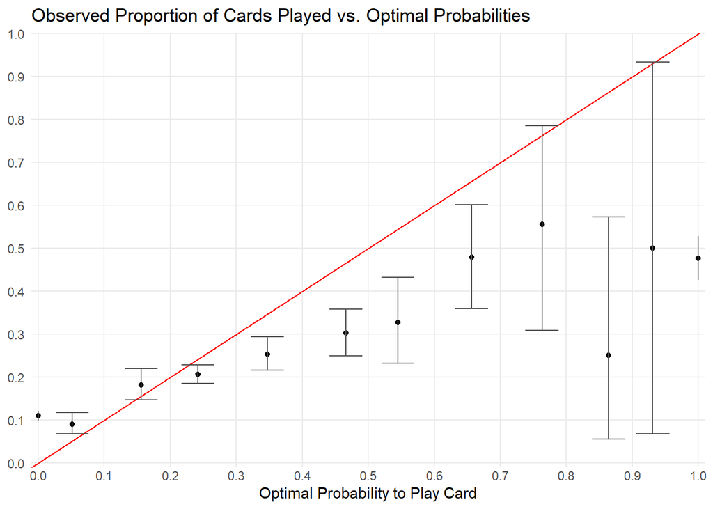

```r
prob_buckets%>%
  ggplot(aes(x = avg_prop_in_bucket, y = prop_played)) + #, size = n_opportunities
  geom_point(stat = "identity")  +
  geom_abline(intercept = 0, slope = 1, color = "red") +
  geom_errorbar(aes(ymin = conf_lower, ymax = conf_upper), width = 0.05, size = 0.5, color = "grey33") + # Add confidence intervals

  scale_x_continuous(limits = c(0, 1),
                     expand = expansion(add = c(0.01,0.01)),
                     breaks = seq(0, 1, length.out = 11)) +
  scale_y_continuous(limits = c(0, 1),
                     expand = expansion(add = c(0.01,0.001)),
                     breaks = seq(0, 1, length.out = 11)) +
  labs(title = "Observed Proportion of Cards Played vs. Optimal Probabilities",
       #subtitle = "",
       x = "Optimal Probability to Play Card",
       y = "% played")  +
  theme_minimal() +
  theme(
    # Remove the y-axis
    axis.title.y = element_blank(),
    panel.grid.minor = element_blank(),

    # Set x-axis breaks from 0 to 7
    axis.ticks.length.x = unit(0, "cm") # Adjust tick length if needed
  )
```

Separated by card

```r
prob_buckets_by_card <- played_vs_optimal %>%
  mutate(prob_bucket = if_else(optimal_prob == 0 | optimal_prob == 1, optimal_prob, round(optimal_prob*9)/9)) %>%
  group_by(prob_bucket, this_card) %>%
  summarise(n_played = sum(this_card_played),
            n_opportunities = n(),
            prop_played = mean(this_card_played),
            avg_prop_in_bucket = mean(optimal_prob))
prob_buckets_by_card %>%
  arrange(this_card)
```

```
# A tibble: 77 × 6
# Groups:   prob_bucket [10]
   prob_bucket this_card n_played n_opportunities prop_played avg_prop_in_bucket
         <dbl> <chr>        <dbl>           <int>       <dbl>              <dbl>
 1       0     0               77             729      0.106             0.00118
 2       0.111 0                5              36      0.139             0.117
 3       0.222 0                3              15      0.2               0.202
 4       0.333 0                7              48      0.146             0.329
 5       0.444 0               11              40      0.275             0.465
 6       0.556 0                3              11      0.273             0.553
 7       0.667 0                4               9      0.444             0.674
 8       0.778 0                1               3      0.333             0.782
 9       1     0               43              78      0.551             0.999
10       0     1               49             732      0.0669            0.00149
# ℹ 67 more rows
```

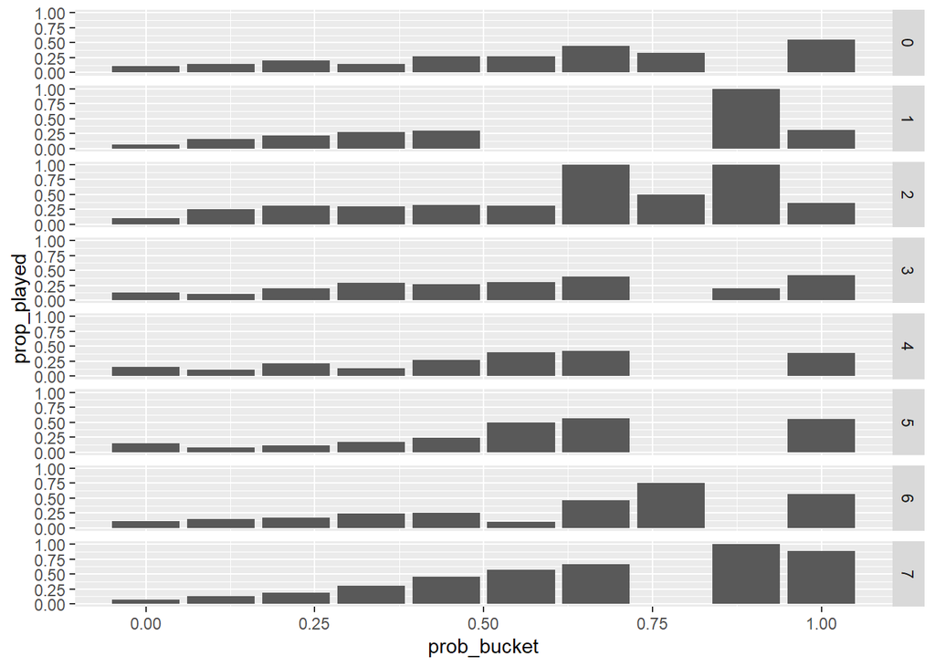

```r
prob_buckets_by_card %>%
  ggplot(aes(x = prob_bucket, y = prop_played)) +
  geom_bar(stat = "identity") +
  facet_grid(rows = vars(this_card))
```

### Impact of errors

When a player makes an “error” how does that affect their “win probability”? Are some players making “errors” that are really beneficial predictions of their opponent’s move?

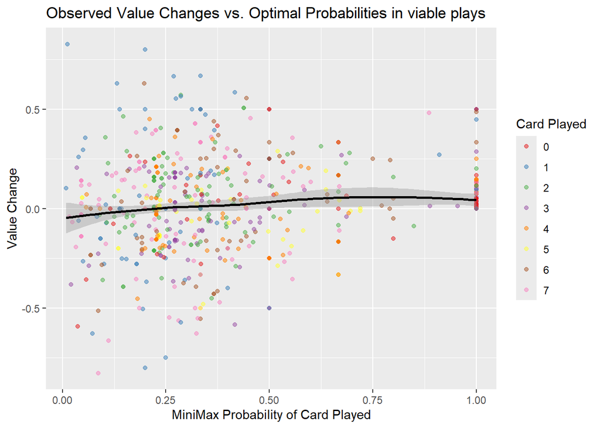

```r
value_changes <- joined_human_ai %>%
  group_by(Game, p1_name) %>%
   # next_turn_value is the value of the next turn. If game is lost, use game outcome
  mutate(next_turn_value = if_else(Turn != max(Turn), lead(value, n=1),
                                if_else(Outcome == "Win", 1, if_else(Outcome == "Loss", 0, 0.5))),
         value_change = next_turn_value - value) %>%
  left_join(played_vs_optimal %>% filter(this_card_played == 1))
# This plot is "Optimal probability of playing the card that was played" vs "change in value of game".
value_changes %>%
  filter(optimal_prob > 0) %>%
  ggplot(aes(x = optimal_prob, y = value_change)) +
  geom_point(aes(color = factor(P1)), alpha = 0.5) +
  geom_smooth(color = "black") +
  scale_color_brewer(palette = "Set1") +
  labs(title = "Observed Value Changes vs. Optimal Probabilities in viable plays",
       color = "Card Played",
       y = "Value Change",
       x = "MiniMax Probability of Card Played")
```

```r
value_changes %>%
  #filter(p1_spy == FALSE & p2_spy == FALSE) %>%
  mutate(abs_mistake = if_else(optimal_prob == 0, "Mistake", "Non-mistake")) %>%
  group_by(abs_mistake) %>%
  summarize(avg_change = mean(value_change),
            std_dev = sd(value_change),
            n = n())
```

```
# A tibble: 2 × 4
  abs_mistake avg_change std_dev     n
  <chr>            <dbl>   <dbl> <int>
1 Mistake        -0.0402   0.210   369
2 Non-mistake     0.0164   0.224   905
```

```r
# t-test on difference (non-spy)
SE = (0.2362542/239 + 0.2356995/797)^0.5
t = (-0.028737909 - 0.008617767)/ SE
df = 239 + 797 - 2

pt(t, df=df, lower.tail=TRUE)
```

```
[1] 0.1487359
```

```r
# t-test on difference (including spy turns)
SE = (0.2104452/369 + 0.2239661/905)^0.5
t = (-0.04017535 - 0.01638089)/ SE
df = 369 + 905 - 2

pt(t, df=df, lower.tail=TRUE)
```

```
[1] 0.02408916
```

### Do some cards tend to increase value?

```r
value_changes %>%
  filter(p1_spy == FALSE & p2_spy == FALSE) %>%
  #mutate(abs_mistake = if_else(optimal_prob == 0, "Mistake", "Non-mistake")) %>%
  group_by(P1) %>%
  summarize(avg_change = mean(value_change),
            std_dev = sd(value_change),
            n = n())
```

```
# A tibble: 8 × 4
     P1 avg_change std_dev     n
  <int>      <dbl>   <dbl> <int>
1     0   -0.0174    0.247    82
2     1    0.00898   0.340   112
3     2    0.0301    0.195   184
4     3   -0.00391   0.187   139
5     4   -0.0123    0.198   134
6     5   -0.0162    0.194   118
7     6    0.00379   0.237   130
8     7   -0.0110    0.286   137
```

# Human EDA

```r
joined_human_ai %>% filter(is.na(value)) %>%
  select(c(paste("p1_c", 0:7, sep=''), paste("p2_c", 0:7, sep=''),
                                                "p1_wins", "p2_wins", "p1_holds", "p2_holds",
                                                "p1_spy", "p2_spy", "p1_general", "p2_general", "Turn", "Game"))
```

```
 [1] p1_c0      p1_c1      p1_c2      p1_c3      p1_c4      p1_c5
 [7] p1_c6      p1_c7      p2_c0      p2_c1      p2_c2      p2_c3
[13] p2_c4      p2_c5      p2_c6      p2_c7      p1_wins    p2_wins
[19] p1_holds   p2_holds   p1_spy     p2_spy     p1_general p2_general
[25] Turn       Game
<0 rows> (or 0-length row.names)
```

```r
joined_human_ai %>%
  filter(Game==1)
```

```
   Game Winner Turn P1 P2 P1_Prev P2_Prev p1_general p2_general Round_Winner_P2
1     1      1    1  2  2      -1      -1      FALSE      FALSE           FALSE
2     1      1    2  7  5       2       2      FALSE      FALSE           FALSE
3     1      1    3  4  4       7       5      FALSE      FALSE           FALSE
4     1      1    4  0  1       4       4      FALSE      FALSE           FALSE
5     1      1    5  6  3       0       1      FALSE      FALSE            TRUE
6     1      0    1  2  2      -1      -1      FALSE      FALSE           FALSE
7     1      0    2  5  7       2       2      FALSE      FALSE            TRUE
8     1      0    3  4  4       5       7      FALSE      FALSE           FALSE
9     1      0    4  1  0       4       4      FALSE      FALSE           FALSE
10    1      0    5  3  6       1       0      FALSE      FALSE           FALSE
   p1_holds p2_holds Round_Wins_P1 Round_Wins_P2 Total_Wins_EOT_P1
1         0        0             0             0                 0
2         1        1             2             0                 2
3         0        0             0             0                 2
```

[output cut: 95 more lines]

### Game plots

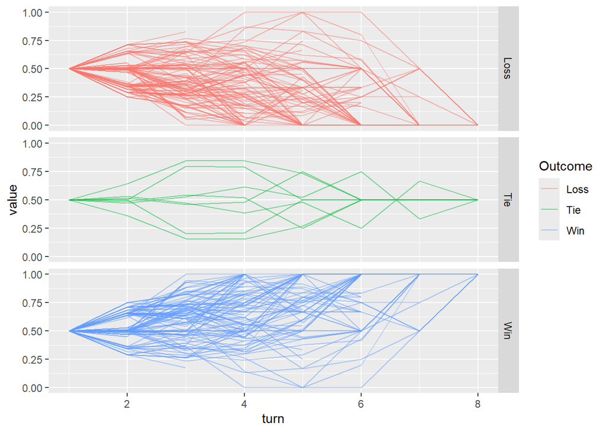

```r
joined_human_ai %>%
  mutate(game_player = str_c("Game",Game,p1_name)) %>%
  ggplot(aes(x = turn, y = value, color=Outcome, group = game_player)) +
  geom_line(alpha = 0.5) +
  facet_grid(rows = vars(Outcome))
```

```r
joined_human_ai %>% filter(value==1, Outcome=="Loss")# %>% select()
```

```
  Game Winner Turn P1 P2 P1_Prev P2_Prev p1_general p2_general Round_Winner_P2
1    7      1    5  6  5       7       6      FALSE       TRUE            TRUE
2   96      1    4  3  2       7       5      FALSE      FALSE            TRUE
3   96      1    5  0  1       3       2      FALSE      FALSE           FALSE
4  123      1    5  0  2       6       7       TRUE      FALSE           FALSE
5  123      1    6  5  1       0       2      FALSE      FALSE           FALSE
  p1_holds p2_holds Round_Wins_P1 Round_Wins_P2 Total_Wins_EOT_P1
1        0        0             0             1                 3
2        0        0             0             1                 3
3        0        0             0             0                 3
4        0        0             0             0                 1
5        1        1             2             0                 3
  Total_Wins_EOT_P2 p1_wins p2_wins p1_c2 p1_c7 p1_c4 p1_c0 p1_c6 p1_c3 p1_c5
1                 2       3       1 FALSE FALSE  TRUE FALSE  TRUE FALSE  TRUE
2                 2       3       1 FALSE FALSE FALSE  TRUE  TRUE  TRUE  TRUE
```

[output cut: 39 more lines]

Number of cards played and turns

```r
joined_human_ai %>% summarize(n = n(), n_turns = n()/2)
```

```
     n n_turns
1 1274     637
```

### Turns per game

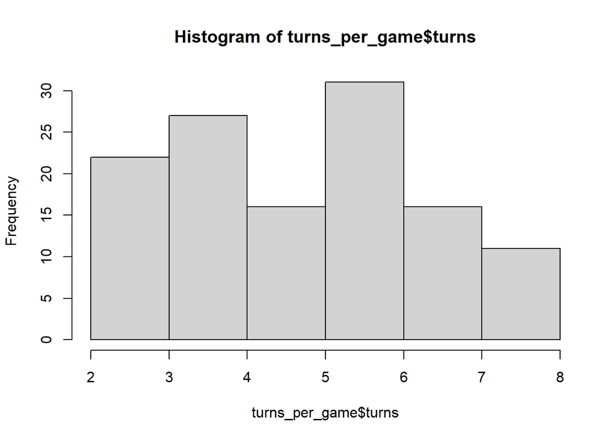

```r
turns_per_game <- joined_human_ai %>%
  group_by(Game) %>%
  summarize(turns = max(turn))

n_games <- nrow(turns_per_game)

hist(turns_per_game$turns)
```

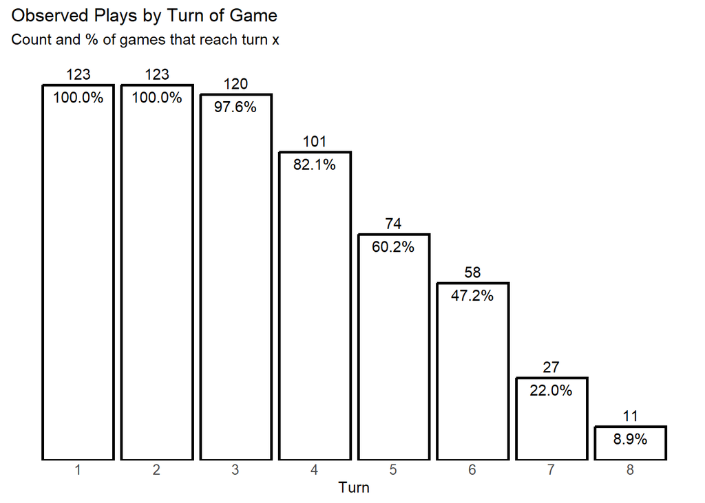

```r
joined_human_ai %>%
  filter(Flipped == FALSE) %>%
  ggplot(aes(x=turn)) +
  geom_bar(fill = 'white', color = "black", size = 1) +
  geom_text(aes(label = ..count..),
            stat = 'count',
            vjust = -0.5,  # Vertical adjustment for count
            color = 'black') +
  geom_text(aes(label = scales::percent(..count.. / n_games, accuracy = 0.1)),
            stat = 'count',
            vjust = 1.5,  # Vertical adjustment for proportion
            color = 'black') +
  labs(title = "Observed Plays by Turn of Game",
       subtitle = "Count and % of games that reach turn x",
       x = "Turn",
       y = "Games")  +
  theme_minimal() +
  theme(
    # Remove the y-axis
    axis.title.y = element_blank(),
    axis.text.y = element_blank(),
    # Remove grid lines
    panel.grid.major = element_blank(),
    panel.grid.minor = element_blank(),
    # Set x-axis breaks from 0 to 7
    axis.ticks.x = element_line(),
    axis.text.x = element_text(size = 10),
    axis.ticks.length.x = unit(0, "cm"),  # Adjust tick length if needed
  ) +
  scale_x_continuous(breaks = 1:8) +
  scale_y_continuous(expand = expansion(add = c(0,10)))
```

```r
mean(turns_per_game$turns)
```

```
[1] 5.178862
```

Distinct Game States

```r
joined_human_ai %>%
  distinct(gamestate_str) %>%
  nrow()
```

```
[1] 733
```

# Human first turn dependence analysis

Count of games by player

```r
player_game_counts <- joined_human_ai %>%
  filter(turn==1) %>%
  group_by(p1_name) %>%
  summarize(n_games = n()) %>%
  arrange(desc(n_games)) %>%
  # Create anonymous player codes
  mutate(player_code = paste("Player", LETTERS[1:length(p1_name)]))

frequent_players <- player_game_counts %>%
  filter(n_games > 20) %>%
  pull(p1_name)

player_game_counts %>%
  filter(p1_name %in% frequent_players)
```

```
# A tibble: 4 × 3
  p1_name n_games player_code
  <chr>     <int> <chr>
1 William     115 Player A
2 Sean         31 Player B
3 Kiran        26 Player C
4 Michael      26 Player D
```

## Just P1’s card

```r
first_card_relationships <- joined_human_ai %>%
  filter(turn == 1, p1_name %in% frequent_players) %>%
  group_by(p1_name) %>%
  arrange(Game, Turn) %>%
  mutate(previous_game_first_card = lag(P1, 1)) %>%
  rename(first_card = P1) %>%
  ungroup() %>%
  filter(!is.na(previous_game_first_card)) %>%
  group_by(previous_game_first_card, first_card, p1_name) %>%
  summarize(n = n())
```

```
You can override using the `.groups` argument.
```

```r
first_card_relationships %>%
  pivot_wider(names_from = first_card, values_from = n, values_fill = 0) %>%
  arrange(p1_name) %>%
  select(previous_game_first_card, p1_name, `0`, `1`, `2`, `3`, `4`, `5`, `6`, `7`)
```

```
# A tibble: 26 × 10
# Groups:   previous_game_first_card [8]
   previous_game_first_card p1_name   `0`   `1`   `2`   `3`   `4`   `5`   `6`
                      <int> <chr>   <int> <int> <int> <int> <int> <int> <int>
 1                        0 Kiran       0     0     0     0     0     1     0
 2                        1 Kiran       1     0     0     0     0     0     0
 3                        2 Kiran       0     0     0     0     4     2     0
 4                        3 Kiran       0     0     0     0     0     0     1
 5                        4 Kiran       0     0     3     0     2     2     1
 6                        5 Kiran       0     0     1     1     2     0     0
 7                        6 Kiran       0     1     1     0     0     0     0
 8                        7 Kiran       0     0     0     0     1     0     0
 9                        2 Michael     0     0     4     3     2     0     1
10                        3 Michael     0     0     2     1     1     1     1
# ℹ 16 more rows
# ℹ 1 more variable: `7` <int>
```

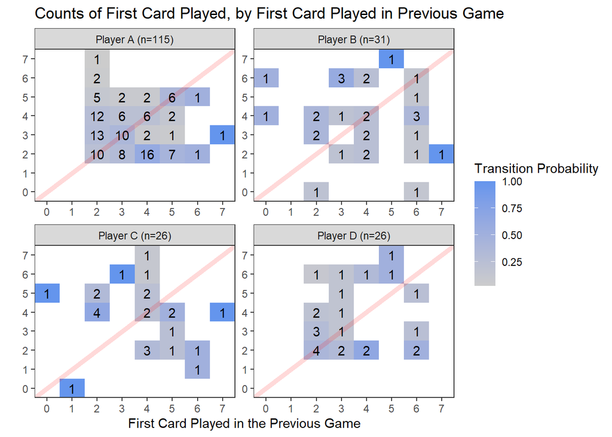

```r
# Excluding 0's
first_card_relationships %>%
  merge(player_game_counts, by="p1_name") %>%
  mutate(p1_name_label = paste(player_code, " (n=", as.character(n_games), ")", sep = "")) %>%
  group_by(p1_name, previous_game_first_card) %>%
  mutate(`Transition Probability` = n/sum(n),
         first_card = factor(first_card, levels = c(0,1,2,3,4,5,6,7)),
         previous_game_first_card = factor(previous_game_first_card, levels = c(0,1,2,3,4,5,6,7))) %>%
  ggplot(aes(x = previous_game_first_card, y = first_card)) +

  geom_tile(aes(fill = `Transition Probability`)) +

  geom_abline(intercept = 0, slope = 1, color = "red", size=2, alpha = 0.15) +
  geom_text(aes(label = n)) +

  facet_wrap(~p1_name_label, axes = "all") +
  scale_x_discrete(expand = c(0,0)) +
  scale_y_discrete(expand = c(0,0)) +
  scale_fill_gradient(low = "gray80", high = "cornflowerblue") + # Adjust the colors here

  theme_bw() +
  theme(
    panel.grid.major = element_blank(),
    panel.grid.minor = element_line(color = "gray", size = 0.5)
  ) +
  labs(title = "Counts of First Card Played, by First Card Played in Previous Game",
       x = "First Card Played in the Previous Game",
       y = "")
```

## Win/Loss Change/Stay

```r
first_outcome_relationships <- joined_human_ai %>%
  filter(turn == 1, p1_name %in% frequent_players) %>%
  group_by(p1_name) %>%
  arrange(Game, Turn) %>%
  mutate(previous_game_first_card = lag(P1, 1),
         stay_or_change = ifelse(P1 == previous_game_first_card, "Stay", "Change"),
         previous_game_first_outcome = lag(Round_Winner, 1)) %>%
  rename(first_card = P1) %>%
  ungroup() %>%
  filter(!is.na(previous_game_first_card)) %>%
  group_by(p1_name, stay_or_change, previous_game_first_outcome) %>%
  summarize(n = n())
first_outcome_relationships %>%
  pivot_wider(names_from = stay_or_change, values_from = n, values_fill = 0) %>%
  mutate(total = Change + Stay) %>%
  arrange(p1_name, previous_game_first_outcome)
```

```
# A tibble: 12 × 5
# Groups:   p1_name [4]
   p1_name previous_game_first_outcome Change  Stay total
   <chr>   <chr>                        <int> <int> <int>
 1 Kiran   Loss                             7     1     8
 2 Kiran   Tie                              3     1     4
 3 Kiran   Win                             13     0    13
 4 Michael Loss                             7     3    10
 5 Michael Tie                              4     2     6
 6 Michael Win                              9     0     9
 7 Sean    Loss                             8     2    10
 8 Sean    Tie                              7     0     7
 9 Sean    Win                             12     1    13
10 William Loss                            34    19    53
11 William Tie                             16     6    22
12 William Win                             32     7    39
```